# Synthetic Data Generation Workflow - Bank Marketing Data

Synthetic data is artificially generated data that mimics the statistical properties of a real dataset (e.g. column structure, distributions, relationships between variables). It is useful for sharing data safely, augmenting datasets, and testing pipelines without exposing sensitive information.

This notebook shows a synthetic data generation workflow using the [Synthetic Data Vault (SDV)](https://sdv.dev/) library and a marketing dataset.

The dataset represents a bank marketing campaign from [UCI Machine Learning Repository](https://archive.ics.uci.edu/dataset/222/bank+marketing), with 4,119 records, 21 variables, and mixed numeric and categorical types.

The goal is to generate a synthetic version of the dataset that preserves the statistical properties of the original, including column distributions, inter-variable correlations, and category adherence.

The final model used in this workflow is SDV's `CopulaGANSynthesizer`, a hybrid approach that combines Gaussian copula marginal fitting with CTGAN-based joint distribution learning. Four synthesizers were evaluated in total; see the Synthetic Data Generation section for a discussion of the tradeoffs.

The notebook is organized as follows:

- **Data Description**: discussion of context, interesting variables, and missing values
- **Data Loading**: schema definition, ingestion, and data summary
- **Synthetic Data Generation**: metadata detection, model training, and sampling
- **Synthetic Data Validation**: distribution comparison, correlation analysis, quality scores, and constraint checks
- **Save Outputs**: save synthetic dataset, fitted model, and metadata to disk
- **Conditional Generation**: brief demo of SDV's conditional generation functionality

# Data Description

The dataset comes from direct marketing campaigns run by a Portuguese bank between 2008 and 2013. Each record represents one client contact (by phone), with the target variable `y` indicating whether the client subscribed to a term deposit.

Variables fall into three groups:

- **Client attributes**: age, job, marital status, education, and whether the client has credit in default, a housing loan, or a personal loan
- **Campaign contact info**: contact type, month, day of week, call duration, and number of contacts in the current campaign
- **Economic context**: employment variation rate, consumer price index, consumer confidence index, Euribor 3-month rate, and number of employees

**Note on `pdays`**: This variable records the number of days since the client was last contacted in a *previous* campaign. The value 999 means they were never previously contacted, which accounts for about 96% of rows. This is a sentinel value, not missing data, and it makes `pdays` effectively bimodal, which will show up in the validation results.

**Note on missing values**: Some columns (e.g. `default`, `housing`, and `loan`) contain an `unknown` category which we treat as a valid category rather than imputing or converting to `NaN`. This preserves the information that the value was unknown at the time of contact. Otherwise, the dataset has no true missing values.

## Data Loading

We define a schema with data types for each column and then load the data.

```python
import pandas as pd
import numpy as np
from minieda import summarize
import sdv
from sdv.metadata import Metadata
from sdv.single_table import CopulaGANSynthesizer
from sdv.evaluation.single_table import evaluate_quality
from sdv.evaluation.single_table import run_diagnostic

from sdmetrics.single_table import NewRowSynthesis
from sdmetrics.single_table import DCRBaselineProtection

from sdv.sampling import Condition

import matplotlib.pyplot as plt
import os
import warnings

warnings.filterwarnings('ignore', category=FutureWarning)
warnings.filterwarnings('ignore', category=UserWarning)

print(pd.__version__)
print(sdv.__version__)
```

```
2.2.3
1.34.2
```

```python
# Function for printing tables
def style_table(df, caption, precision=1, caption_side="bottom", font_size="16px", font_weight="normal"):
    return (df.style
            .format(precision=precision).set_caption(caption)
            .set_table_styles([{"selector": "caption",
                                "props": [("caption-side", caption_side),
                                          ("font-size", font_size),
                                          ("font-weight", font_weight)]}]))
```

```python
data_schema = {
    'age':              'int64',      # client age
    'job':              'category',   # type of job (admin, blue-collar, entrepreneur, housemaid, management, retired, self-employed, services, student, technician, unemployed, unknown)
    'marital':          'category',   # marital status (divorced, married, single, unknown)
    'education':        'category',   # education level (basic.4y, basic.6y, basic.9y, high.school, illiterate, professional.course, university.degree, unknown)
    'default':          'category',   # has credit in default? (yes, no, unknown)
    'housing':          'category',   # has housing loan? (yes, no, unknown)
    'loan':             'category',   # has personal loan? (yes, no, unknown)
    'contact':          'category',   # contact communication type (cellular, telephone)
    'month':            'category',   # last contact month of year (jan–dec)
    'day_of_week':      'category',   # last contact day of the week (mon, tue, wed, thu, fri)
    'duration':         'int64',      # last contact duration in seconds — benchmark only, not for predictive modeling
    'campaign':         'int64',      # number of contacts performed during this campaign (includes last contact)
    'pdays':            'int64',      # days since client was last contacted from previous campaign (999 = not previously contacted)
    'previous':         'int64',      # number of contacts performed before this campaign
    'poutcome':         'category',   # outcome of previous marketing campaign (failure, nonexistent, success)
    'emp.var.rate':     'float64',    # employment variation rate — quarterly indicator
    'cons.price.idx':   'float64',    # consumer price index — monthly indicator
    'cons.conf.idx':    'float64',    # consumer confidence index — monthly indicator
    'euribor3m':        'float64',    # euribor 3 month rate — daily indicator
    'nr.employed':      'float64',    # number of employees — quarterly indicator
    'y':                'category',   # target: has the client subscribed a term deposit? (yes, no)
}

# Load data with schema
data = pd.read_csv('data/bank-additional.csv', sep=";", dtype=data_schema)

# Convert yes/no columns to True/False
bool_cols = ['y']
for col in bool_cols:
    data[col] = data[col].map({'yes': True, 'no': False})
```

```python
summarize(data)
```

|  | dtype | count | unique | unique_pct | missing | missing_pct | zero | zero_pct | top | freq | mean | std | min | 50% | max | skew |
| --- | --- | --- | --- | --- | --- | --- | --- | --- | --- | --- | --- | --- | --- | --- | --- | --- |
| age | int64 | 4119 | 67 | 1.63 | 0 | 0.0 | 0 | 0.00 |  |  | 40.11 | 10.31 | 18.0 | 38.0 | 88.0 | 0.72 |
| campaign | int64 | 4119 | 25 | 0.61 | 0 | 0.0 | 0 | 0.00 |  |  | 2.54 | 2.57 | 1.0 | 2.0 | 35.0 | 4.0 |
| nr.employed | float64 | 4119 | 11 | 0.27 | 0 | 0.0 | 0 | 0.00 |  |  | 5166.48 | 73.67 | 4963.6 | 5191.0 | 5228.1 | -1.08 |
| euribor3m | float64 | 4119 | 234 | 5.68 | 0 | 0.0 | 0 | 0.00 |  |  | 3.62 | 1.73 | 0.64 | 4.86 | 5.04 | -0.72 |
| cons.conf.idx | float64 | 4119 | 26 | 0.63 | 0 | 0.0 | 0 | 0.00 |  |  | -40.5 | 4.59 | -50.8 | -41.8 | -26.9 | 0.29 |
| cons.price.idx | float64 | 4119 | 26 | 0.63 | 0 | 0.0 | 0 | 0.00 |  |  | 93.58 | 0.58 | 92.2 | 93.75 | 94.77 | -0.22 |
| emp.var.rate | float64 | 4119 | 10 | 0.24 | 0 | 0.0 | 0 | 0.00 |  |  | 0.08 | 1.56 | -3.4 | 1.1 | 1.4 | -0.73 |
| previous | int64 | 4119 | 7 | 0.17 | 0 | 0.0 | 3523 | 85.53 |  |  | 0.19 | 0.54 | 0.0 | 0.0 | 6.0 | 4.02 |
| pdays | int64 | 4119 | 21 | 0.51 | 0 | 0.0 | 2 | 0.05 |  |  | 960.42 | 191.92 | 0.0 | 999.0 | 999.0 | -4.78 |
| duration | int64 | 4119 | 828 | 20.10 | 0 | 0.0 | 1 | 0.02 |  |  | 256.79 | 254.7 | 0.0 | 181.0 | 3643.0 | 3.29 |
| job | category | 4119 | 12 | 0.29 | 0 | 0.0 | 0 | 0.00 | admin. | 1012 |  |  |  |  |  |  |
| day_of_week | category | 4119 | 5 | 0.12 | 0 | 0.0 | 0 | 0.00 | thu | 860 |  |  |  |  |  |  |
| month | category | 4119 | 10 | 0.24 | 0 | 0.0 | 0 | 0.00 | may | 1378 |  |  |  |  |  |  |
| contact | category | 4119 | 2 | 0.05 | 0 | 0.0 | 0 | 0.00 | cellular | 2652 |  |  |  |  |  |  |
| poutcome | category | 4119 | 3 | 0.07 | 0 | 0.0 | 0 | 0.00 | nonexistent | 3523 |  |  |  |  |  |  |
| loan | category | 4119 | 3 | 0.07 | 0 | 0.0 | 0 | 0.00 | no | 3349 |  |  |  |  |  |  |
| housing | category | 4119 | 3 | 0.07 | 0 | 0.0 | 0 | 0.00 | yes | 2175 |  |  |  |  |  |  |
| default | category | 4119 | 3 | 0.07 | 0 | 0.0 | 0 | 0.00 | no | 3315 |  |  |  |  |  |  |
| education | category | 4119 | 8 | 0.19 | 0 | 0.0 | 0 | 0.00 | university.degree | 1264 |  |  |  |  |  |  |
| marital | category | 4119 | 4 | 0.10 | 0 | 0.0 | 0 | 0.00 | married | 2509 |  |  |  |  |  |  |
| y | category | 4119 | 2 | 0.05 | 0 | 0.0 | 0 | 0.00 | False | 3668 |  |  |  |  |  |  |

## Synthetic Data Generation

Three other synthesizers were evaluated (code and results not shown in this notebook):

- `GaussianCopulaSynthesizer` produced good validity and privacy scores but systematically miscalibrated heavily imbalanced categorical columns, inflating the `unknown` category in `default` and `marital` to become the dominant value in the synthetic data.
- `CTGANSynthesizer` failed to reproduce inter-variable correlations at this dataset size, producing a near-flat correlation matrix.
- `TVAESynthesizer` dropped minority categories entirely for several columns including `loan` and `marital`.

We sample 4,119 rows (same as the original dataset).

```python
metadata = Metadata.detect_from_dataframe(data=data, table_name='bank_marketing')

# CopulaGAN requires categorical columns to be `object` dtype instead of pandas' `category`
data_copulagan = data.copy()
cat_cols = data.select_dtypes('category').columns
data_copulagan[cat_cols] = data_copulagan[cat_cols].astype(object)

# Instantiate and fit the model
synthesizer = CopulaGANSynthesizer(metadata, epochs=150, verbose=True)
synthesizer.fit(data_copulagan)

# Generate synthetic data, with the same number of rows as the original dataset
synthetic_data = synthesizer.sample(num_rows=data_copulagan.shape[0])

# Restore category dtype to match real data (CopulaGAN outputs object dtype)
synthetic_data[cat_cols] = synthetic_data[cat_cols].astype('category')

print(synthetic_data.shape)
```

```
(4119, 21)
```

```python
synthetic_data.head()
```

|  | age | job | marital | education | default | housing | loan | contact | month | day_of_week | ... | campaign | pdays | previous | poutcome | emp.var.rate | cons.price.idx | cons.conf.idx | euribor3m | nr.employed | y |
| --- | --- | --- | --- | --- | --- | --- | --- | --- | --- | --- | --- | --- | --- | --- | --- | --- | --- | --- | --- | --- | --- |
| 0 | 49 | technician | single | university.degree | unknown | no | no | cellular | jul | mon | ... | 7 | 999 | 0 | nonexistent | 1.4 | 94.500 | -42.3 | 4.967 | 5228.1 | False |
| 1 | 50 | blue-collar | married | basic.4y | no | yes | no | telephone | jun | mon | ... | 2 | 999 | 0 | nonexistent | 1.4 | 93.950 | -36.3 | 4.145 | 5228.1 | False |
| 2 | 50 | blue-collar | single | basic.6y | no | yes | no | cellular | jul | tue | ... | 6 | 999 | 0 | nonexistent | 1.2 | 93.546 | -35.9 | 4.955 | 5228.1 | False |
| 3 | 36 | technician | married | basic.9y | no | yes | yes | cellular | jul | wed | ... | 4 | 999 | 0 | nonexistent | 1.4 | 94.097 | -36.7 | 4.980 | 5228.1 | False |
| 4 | 88 | admin. | single | university.degree | no | yes | no | cellular | apr | thu | ... | 1 | 4 | 1 | failure | -1.7 | 93.007 | -26.9 | 1.085 | 5007.6 | True |

5 rows × 21 columns

```python
summarize(synthetic_data)
```

|  | dtype | count | unique | unique_pct | missing | missing_pct | zero | zero_pct | top | freq | mean | std | min | 50% | max | skew |
| --- | --- | --- | --- | --- | --- | --- | --- | --- | --- | --- | --- | --- | --- | --- | --- | --- |
| age | int64 | 4119 | 68 | 1.65 | 0 | 0.0 | 0 | 0.00 |  |  | 47.81 | 14.07 | 20.0 | 46.0 | 88.0 | 0.73 |
| campaign | int64 | 4119 | 33 | 0.80 | 0 | 0.0 | 0 | 0.00 |  |  | 3.16 | 4.15 | 1.0 | 2.0 | 34.0 | 3.75 |
| nr.employed | float64 | 4119 | 1453 | 35.28 | 0 | 0.0 | 0 | 0.00 |  |  | 5142.09 | 86.9 | 4963.6 | 5178.9 | 5228.1 | -0.72 |
| euribor3m | float64 | 4119 | 1462 | 35.49 | 0 | 0.0 | 0 | 0.00 |  |  | 3.36 | 1.73 | 0.64 | 4.31 | 4.99 | -0.36 |
| cons.conf.idx | float64 | 4119 | 221 | 5.37 | 0 | 0.0 | 0 | 0.00 |  |  | -39.34 | 5.6 | -50.8 | -41.3 | -26.9 | 0.56 |
| cons.price.idx | float64 | 4119 | 1392 | 33.79 | 0 | 0.0 | 0 | 0.00 |  |  | 93.56 | 0.59 | 92.2 | 93.49 | 94.77 | -0.03 |
| emp.var.rate | float64 | 4119 | 49 | 1.19 | 0 | 0.0 | 19 | 0.46 |  |  | -0.15 | 1.65 | -3.4 | 0.7 | 1.4 | -0.55 |
| previous | int64 | 4119 | 7 | 0.17 | 0 | 0.0 | 3090 | 75.02 |  |  | 0.41 | 0.92 | 0.0 | 0.0 | 6.0 | 3.2 |
| pdays | int64 | 4119 | 190 | 4.61 | 0 | 0.0 | 59 | 1.43 |  |  | 858.2 | 336.89 | 0.0 | 999.0 | 999.0 | -1.99 |
| duration | int64 | 4119 | 1240 | 30.10 | 0 | 0.0 | 0 | 0.00 |  |  | 482.64 | 546.12 | 4.0 | 307.0 | 3643.0 | 2.83 |
| job | category | 4119 | 12 | 0.29 | 0 | 0.0 | 0 | 0.00 | blue-collar | 889 |  |  |  |  |  |  |
| day_of_week | category | 4119 | 5 | 0.12 | 0 | 0.0 | 0 | 0.00 | tue | 1166 |  |  |  |  |  |  |
| month | category | 4119 | 10 | 0.24 | 0 | 0.0 | 0 | 0.00 | may | 920 |  |  |  |  |  |  |
| contact | category | 4119 | 2 | 0.05 | 0 | 0.0 | 0 | 0.00 | cellular | 3016 |  |  |  |  |  |  |
| poutcome | category | 4119 | 3 | 0.07 | 0 | 0.0 | 0 | 0.00 | nonexistent | 3178 |  |  |  |  |  |  |
| loan | category | 4119 | 3 | 0.07 | 0 | 0.0 | 0 | 0.00 | no | 2695 |  |  |  |  |  |  |
| housing | category | 4119 | 3 | 0.07 | 0 | 0.0 | 0 | 0.00 | yes | 2561 |  |  |  |  |  |  |
| default | category | 4119 | 3 | 0.07 | 0 | 0.0 | 0 | 0.00 | no | 3186 |  |  |  |  |  |  |
| education | category | 4119 | 8 | 0.19 | 0 | 0.0 | 0 | 0.00 | high.school | 1153 |  |  |  |  |  |  |
| marital | category | 4119 | 4 | 0.10 | 0 | 0.0 | 0 | 0.00 | married | 1927 |  |  |  |  |  |  |
| y | category | 4119 | 2 | 0.05 | 0 | 0.0 | 0 | 0.00 | False | 3168 |  |  |  |  |  |  |

## Synthetic Data Validation

In this section, we use several methods to check how the synthetic data compares to the original dataset.

### Per-variable Distribution Comparison

We plot each column of the real and synthetic data side-by-side using KDE curves for numeric columns and grouped bar plots for categorical columns.

A well-fitting synthetic dataset should show close overlap throughout.

The table below the plots summarizes mean, std, min, and max for the numeric columns.

There is a noticeable difference in the means of several features, e.g. `duration`, `previous`, `emp.var.rate`.

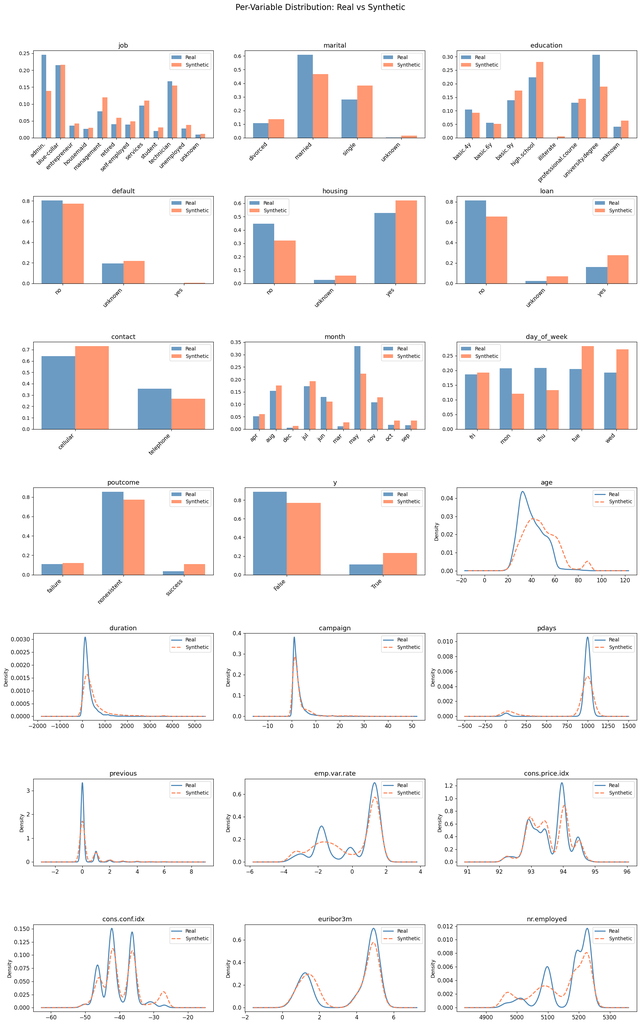

```python
categorical_cols = ['job', 'marital', 'education', 'default', 'housing', 'loan',
                    'contact', 'month', 'day_of_week', 'poutcome']
boolean_cols     = ['y']
numeric_cols     = ['age', 'duration', 'campaign', 'pdays', 'previous',
                    'emp.var.rate', 'cons.price.idx', 'cons.conf.idx',
                    'euribor3m', 'nr.employed']

all_cols = categorical_cols + boolean_cols + numeric_cols
n_cols   = len(all_cols)

# Set up grid
n_grid_cols = 3
n_grid_rows = int(np.ceil(n_cols / n_grid_cols))

fig, axes = plt.subplots(n_grid_rows, n_grid_cols, figsize=(18, n_grid_rows * 4))
axes = axes.flatten()

for i, col in enumerate(all_cols):
    ax = axes[i]

    if col in numeric_cols:
        # Overlapping KDE plots for numeric columns
        data[col].plot.kde(ax=ax, label='Real', color='steelblue', linewidth=2)
        synthetic_data[col].plot.kde(ax=ax, label='Synthetic', color='coral',
                                      linewidth=2, linestyle='--')
        ax.set_title(col, fontsize=13)
        ax.legend()
        ax.tick_params(axis='both', labelsize=11)

    else:
        # Grouped bar chart for categorical and boolean columns
        real_counts = data[col].value_counts(normalize=True).sort_index()
        synth_counts = synthetic_data[col].value_counts(normalize=True).sort_index()

        # Align categories in case synthetic has different order
        all_categories = sorted(set(real_counts.index) | set(synth_counts.index),
                                key=str)
        real_counts  = real_counts.reindex(all_categories, fill_value=0)
        synth_counts = synth_counts.reindex(all_categories, fill_value=0)

        x = np.arange(len(all_categories))
        width = 0.35

        ax.bar(x - width/2, real_counts.values,  width, label='Real',
               color='steelblue', alpha=0.8)
        ax.bar(x + width/2, synth_counts.values, width, label='Synthetic',
               color='coral', alpha=0.8)

        ax.set_xticks(x)
        ax.set_xticklabels(all_categories, rotation=45, ha='right', fontsize=11)
        ax.set_title(col, fontsize=13)
        ax.legend()

# Hide any unused subplots
for j in range(i + 1, len(axes)):
    axes[j].set_visible(False)

plt.suptitle('Per-Variable Distribution: Real vs Synthetic', fontsize=16, y=1.02)
plt.tight_layout()
plt.show()
```

```python
real_stats  = data[numeric_cols].describe().T[['mean', 'std', 'min', 'max']]
synth_stats = synthetic_data[numeric_cols].describe().T[['mean', 'std', 'min', 'max']]

real_stats.columns  = ['real_mean', 'real_std', 'real_min', 'real_max']
synth_stats.columns = ['synth_mean', 'synth_std', 'synth_min', 'synth_max']

summary = pd.concat([real_stats, synth_stats], axis=1)
style_table(summary.round(3), caption="Numeric Column Statistics: Real vs Synthetic")
```

Numeric Column Statistics: Real vs Synthetic

|  | real_mean | real_std | real_min | real_max | synth_mean | synth_std | synth_min | synth_max |
| --- | --- | --- | --- | --- | --- | --- | --- | --- |
| age | 40.1 | 10.3 | 18.0 | 88.0 | 47.8 | 14.1 | 20.0 | 88.0 |
| duration | 256.8 | 254.7 | 0.0 | 3643.0 | 482.6 | 546.1 | 4.0 | 3643.0 |
| campaign | 2.5 | 2.6 | 1.0 | 35.0 | 3.2 | 4.1 | 1.0 | 34.0 |
| pdays | 960.4 | 191.9 | 0.0 | 999.0 | 858.2 | 336.9 | 0.0 | 999.0 |
| previous | 0.2 | 0.5 | 0.0 | 6.0 | 0.4 | 0.9 | 0.0 | 6.0 |
| emp.var.rate | 0.1 | 1.6 | -3.4 | 1.4 | -0.1 | 1.6 | -3.4 | 1.4 |
| cons.price.idx | 93.6 | 0.6 | 92.2 | 94.8 | 93.6 | 0.6 | 92.2 | 94.8 |
| cons.conf.idx | -40.5 | 4.6 | -50.8 | -26.9 | -39.3 | 5.6 | -50.8 | -26.9 |
| euribor3m | 3.6 | 1.7 | 0.6 | 5.0 | 3.4 | 1.7 | 0.6 | 5.0 |
| nr.employed | 5166.5 | 73.7 | 4963.6 | 5228.1 | 5142.1 | 86.9 | 4963.6 | 5228.1 |

## Correlation Structure

Beyond individual column distributions, a synthetic dataset should preserve relationships between variables. We first compare numeric correlation matrices visually using heatmaps. Then we use SDV's `evaluate_quality` function to compute Column Pair Trends scores.

Column Pair Trends evaluates two types of relationships:

- **Numeric-numeric pairs** (Correlation Similarity): how well linear correlations between numeric columns are reproduced
- **Categorical/mixed pairs** (Contingency Similarity): how well associations between categorical columns, and between categorical and numeric columns, are preserved

Each row in the tables below represents a column pair. The Score measures how well the relationship was preserved in the synthetic data, from 0 (not preserved) to 1 (perfectly preserved). The tables below show only column pairs that meet SDV's association threshold; pairs where the real data shows a weak relationship are excluded.

We also compute mean scores to summarize performance of each of the pair types.

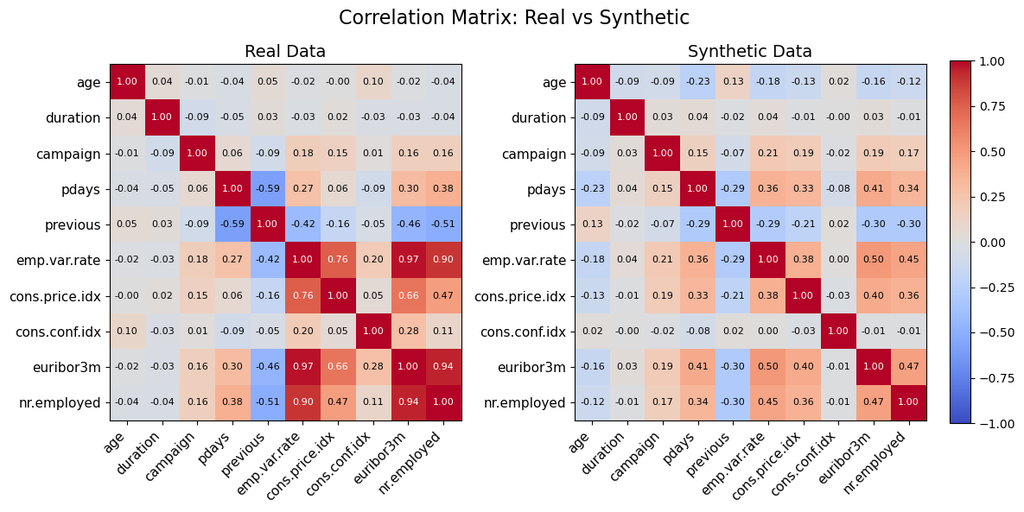

```python
fig, axes = plt.subplots(1, 2, figsize=(12, 6))

real_corr  = data[numeric_cols].corr()
synth_corr = synthetic_data[numeric_cols].corr()

# Shared color scale
vmin, vmax = -1, 1

for ax, corr, title in zip(axes, [real_corr, synth_corr], ['Real Data', 'Synthetic Data']):
    im = ax.imshow(corr, cmap='coolwarm', vmin=vmin, vmax=vmax, aspect='auto')
    ax.set_xticks(range(len(numeric_cols)))
    ax.set_yticks(range(len(numeric_cols)))
    ax.set_xticklabels(numeric_cols, rotation=45, ha='right', fontsize=11)
    ax.set_yticklabels(numeric_cols, fontsize=11)
    ax.set_title(title, fontsize=14)

    # Annotate cells with correlation values
    for i in range(len(numeric_cols)):
        for j in range(len(numeric_cols)):
            ax.text(j, i, f'{corr.iloc[i, j]:.2f}',
                    ha='center', va='center', fontsize=8,
                    color='white' if abs(corr.iloc[i, j]) > 0.6 else 'black')

# Dedicated colorbar axis
cbar_ax = fig.add_axes([0.92, 0.18, 0.02, 0.7])  # [left, bottom, width, height]
fig.colorbar(im, cax=cbar_ax)

plt.suptitle('Correlation Matrix: Real vs Synthetic', fontsize=16)
plt.tight_layout(rect=[0, 0, 0.91, 1])
plt.show()
```

```python
quality_report = evaluate_quality(
    real_data=data,
    synthetic_data=synthetic_data,
    metadata=metadata,
    verbose=False
)

pair_trends = quality_report.get_details(property_name='Column Pair Trends')
pair_trends_nona = pair_trends.dropna(subset=['Score'])

# Split into correlation (numeric-numeric) and contingency (categorical) pairs
correlation_pairs = pair_trends_nona[pair_trends_nona['Metric'] == 'CorrelationSimilarity']
contingency_pairs = pair_trends_nona[pair_trends_nona['Metric'] == 'ContingencySimilarity']
```

```python
style_table(correlation_pairs[['Column 1', 'Column 2', 'Score', 'Real Correlation', 'Synthetic Correlation']],
            caption="Numeric-Numeric Pairs (Correlation Similarity)")
```

Numeric-Numeric Pairs (Correlation Similarity)

|  | Column 1 | Column 2 | Score | Real Correlation | Synthetic Correlation |
| --- | --- | --- | --- | --- | --- |
| 195 | emp.var.rate | cons.price.idx | 0.8 | 0.8 | 0.4 |
| 197 | emp.var.rate | euribor3m | 0.8 | 1.0 | 0.5 |
| 198 | emp.var.rate | nr.employed | 0.8 | 0.9 | 0.4 |
| 201 | cons.price.idx | euribor3m | 0.9 | 0.7 | 0.4 |
| 207 | euribor3m | nr.employed | 0.8 | 0.9 | 0.5 |

```python
style_table(contingency_pairs[['Column 1', 'Column 2', 'Score', 'Real Association']],
            caption="Categorical/Mixed Pairs (Contingency Similarity)")
```

Categorical/Mixed Pairs (Contingency Similarity)

|  | Column 1 | Column 2 | Score | Real Association |
| --- | --- | --- | --- | --- |
| 21 | job | education | 0.6 | 0.4 |
| 90 | housing | loan | 0.8 | 0.7 |
| 119 | contact | month | 0.7 | 0.6 |
| 126 | contact | emp.var.rate | 0.6 | 0.7 |
| 127 | contact | cons.price.idx | 0.6 | 0.7 |
| 128 | contact | cons.conf.idx | 0.7 | 0.4 |
| 129 | contact | euribor3m | 0.8 | 0.5 |
| 130 | contact | nr.employed | 0.7 | 0.5 |
| 138 | month | emp.var.rate | 0.4 | 0.7 |
| 139 | month | cons.price.idx | 0.2 | 0.7 |
| 140 | month | cons.conf.idx | 0.3 | 0.6 |
| 141 | month | euribor3m | 0.5 | 0.5 |
| 142 | month | nr.employed | 0.4 | 0.6 |
| 164 | duration | y | 0.7 | 0.4 |
| 174 | pdays | previous | 0.8 | 0.6 |
| 175 | pdays | poutcome | 0.8 | 0.9 |
| 181 | pdays | y | 0.8 | 0.3 |
| 182 | previous | poutcome | 0.8 | 0.7 |
| 189 | poutcome | emp.var.rate | 0.6 | 0.4 |
| 190 | poutcome | cons.price.idx | 0.6 | 0.4 |
| 191 | poutcome | cons.conf.idx | 0.7 | 0.4 |
| 192 | poutcome | euribor3m | 0.7 | 0.4 |
| 193 | poutcome | nr.employed | 0.6 | 0.4 |
| 194 | poutcome | y | 0.9 | 0.3 |
| 199 | emp.var.rate | y | 0.7 | 0.3 |
| 203 | cons.price.idx | y | 0.6 | 0.3 |
| 206 | cons.conf.idx | y | 0.7 | 0.4 |
| 208 | euribor3m | y | 0.7 | 0.4 |
| 209 | nr.employed | y | 0.7 | 0.4 |

```python
print(f"Numeric-Numeric Pairs Mean Score: {correlation_pairs['Score'].mean():.3f}")
print(f"Categorical/Mixed Pairs Mean Score: {contingency_pairs['Score'].mean():.3f}")
```

```
Numeric-Numeric Pairs Mean Score: 0.798
Categorical/Mixed Pairs Mean Score: 0.644
```

### SDV Quality Scores

SDV's `evaluate_quality` function scores each column individually on how well its distribution was reproduced ('Column Shapes') and each column pair on how well their relationship was preserved ('Column Pair Trends').

We already examined the pair trends above; here we look at the per-column scores.

```python
quality_report.get_details(property_name='Column Shapes')
```

|  | Column | Metric | Score |
| --- | --- | --- | --- |
| 0 | age | KSComplement | 0.764020 |
| 1 | job | TVComplement | 0.879825 |
| 2 | marital | TVComplement | 0.858704 |
| 3 | education | TVComplement | 0.866472 |
| 4 | default | TVComplement | 0.968682 |
| 5 | housing | TVComplement | 0.873513 |
| 6 | loan | TVComplement | 0.841224 |
| 7 | contact | TVComplement | 0.911629 |
| 8 | month | TVComplement | 0.871328 |
| 9 | day_of_week | TVComplement | 0.837096 |
| 10 | duration | KSComplement | 0.749697 |
| 11 | campaign | KSComplement | 0.932993 |
| 12 | pdays | KSComplement | 0.889051 |
| 13 | previous | TVComplement | 0.894877 |
| 14 | poutcome | TVComplement | 0.916242 |
| 15 | emp.var.rate | KSComplement | 0.864530 |
| 16 | cons.price.idx | KSComplement | 0.817674 |
| 17 | cons.conf.idx | KSComplement | 0.815246 |
| 18 | euribor3m | KSComplement | 0.837825 |
| 19 | nr.employed | KSComplement | 0.738043 |
| 20 | y | TVComplement | 0.878611 |

## Privacy and Memorization Checks

We run two checks to confirm that the synthetic data doesn't reproduce records from the training data.

- **New Row Score** (`NewRowSynthesis`): checks whether any synthetic rows are exact copies of real rows. A score of 1.0 means every synthetic row is new.
- **Nearest-Neighbor Privacy Score** (`DCRBaselineProtection`): measures how close synthetic rows are to their nearest real neighbors, relative to a random data baseline. A score of 1.0 means the synthetic data is no closer to the real data than random noise (the best possible privacy). A score near 0.5 is typical for a well-trained model.

```python
metadata_dict = metadata.to_dict()['tables']['bank_marketing']

def to_str_categories(df):
    return df.copy().assign(**{
        col: df[col].astype(str)
        for col in df.select_dtypes('category').columns
    })

new_row_score = NewRowSynthesis.compute(
    real_data=to_str_categories(data),
    synthetic_data=to_str_categories(synthetic_data),
    metadata=metadata_dict,
    numerical_match_tolerance=0.01,
    synthetic_sample_size=None
)

nn_privacy_score = DCRBaselineProtection.compute_breakdown(
    real_data=data,
    synthetic_data=synthetic_data,
    metadata=metadata_dict
)

print(f"New Row Score: {new_row_score:.3f}")
print(f"Nearest-Neighbor Privacy Score: {nn_privacy_score['score']:.3f}")
print(f"Synthetic median DCR to real data: {nn_privacy_score['median_DCR_to_real_data']['synthetic_data']:.3f}")
print(f"Random baseline median DCR to real data: {nn_privacy_score['median_DCR_to_real_data']['random_data_baseline']:.3f}")
```

```
New Row Score: 1.000
Nearest-Neighbor Privacy Score: 0.417
Synthetic median DCR to real data: 0.148
Random baseline median DCR to real data: 0.354
```

### SDV Validity Checks

To conclude this section, we run SDV's built-in [diagnostic report](https://docs.sdv.dev/sdmetrics/data-metrics/diagnostic/diagnostic-report), which captures basic diagnostic measurements across the entire dataset, reporting areas that may be problematic. It checks:

- **Data Structure**: the synthetic table has the same column names as the real data.
- **Data Validity**: synthetic values respect the original data's column types and value ranges.

We expect both the scores to be close to 100%.

```python
diagnostic_report = run_diagnostic(
    real_data=data,
    synthetic_data=synthetic_data,
    metadata=metadata,
    verbose=True
)
```

```
Generating report ...

(1/2) Evaluating Data Validity: |███████████████████████████████████████████████████| 21/21 [00:00<00:00, 1613.70it/s]|
Data Validity Score: 100.0%

(2/2) Evaluating Data Structure: |█████████████████████████████████████████████████████| 1/1 [00:00<00:00, 333.41it/s]|
Data Structure Score: 100.0%

Overall Score (Average): 100.0%
```

### Synthetic Data Quality Summary

The table below summarizes the key validation metrics computed in this section.

- Data Validity and Data Structure should score close to 100%.
- Column Shapes, Column Pair Trends, and the privacy metrics don't have a fixed target; however, higher is better for quality scores, while a Nearest-Neighbor Privacy Score near 0.5 indicates a good balance between utility and privacy.

```python
summary = {
    'Column Shapes':                    quality_report.get_properties().set_index('Property').loc['Column Shapes', 'Score'],
    'Column Pair Trends (numeric)':     correlation_pairs['Score'].mean(),
    'Column Pair Trends (categorical)': contingency_pairs['Score'].mean(),
    'Data Validity':                    diagnostic_report.get_properties().set_index('Property').loc['Data Validity', 'Score'],
    'Data Structure':                   diagnostic_report.get_properties().set_index('Property').loc['Data Structure', 'Score'],
    'New Row Score':                    new_row_score,
    'Nearest-Neighbor Privacy':         nn_privacy_score['score'],
}

summary_df = pd.DataFrame.from_dict(summary, orient='index', columns=['Score'])
style_table(summary_df, caption='Synthetic Data Quality Summary', precision=2)
```

Synthetic Data Quality Summary

|  | Score |
| --- | --- |
| Column Shapes | 0.86 |
| Column Pair Trends (numeric) | 0.80 |
| Column Pair Trends (categorical) | 0.64 |
| Data Validity | 1.00 |
| Data Structure | 1.00 |
| New Row Score | 1.00 |
| Nearest-Neighbor Privacy | 0.42 |

## Save Outputs

For reproducibility, we save the following items:

- The synthetic dataset
- Fitted synthesizer
- Metadata

The synthesizer can be reloaded to generate additional synthetic rows without retraining.

```python
os.makedirs('outputs', exist_ok=True)

# Save synthetic data to CSV
synthetic_data.to_csv('outputs/synthetic_data.csv', index=False)

# Save the fitted synthesizer for reproducibility
synthesizer.save('outputs/copulagan_synthesizer.pkl')

# Save metadata to JSON
metadata.save_to_json('outputs/metadata.json', mode='overwrite')
```

## Conditional Generation

Beyond generating a full synthetic dataset, SDV supports conditional generation: we sample rows that match specified demographic or behavioral criteria while drawing the remaining columns from the learned distribution. This can be useful for generating targeted test datasets, augmenting underrepresented segments, or simulating specific customer profiles.

```python
# Basic example: generate 200 rows for young clients (age 25)
young_condition = Condition(
    num_rows=200,
    column_values={'age': 25}
)
young_synthetic = synthesizer.sample_from_conditions(conditions=[young_condition])
young_synthetic[cat_cols] = young_synthetic[cat_cols].astype('category') # Restore category dtype to match real data (CopulaGAN outputs object dtype)
print(young_synthetic.shape)
young_synthetic.head()
```

```
(200, 21)
```

|  | age | job | marital | education | default | housing | loan | contact | month | day_of_week | ... | campaign | pdays | previous | poutcome | emp.var.rate | cons.price.idx | cons.conf.idx | euribor3m | nr.employed | y |
| --- | --- | --- | --- | --- | --- | --- | --- | --- | --- | --- | --- | --- | --- | --- | --- | --- | --- | --- | --- | --- | --- |
| 0 | 25 | blue-collar | married | university.degree | unknown | yes | unknown | telephone | may | thu | ... | 2 | 999 | 0 | failure | 1.0 | 93.997 | -36.5 | 4.928 | 5169.5 | False |
| 1 | 25 | unemployed | single | university.degree | no | no | yes | cellular | mar | wed | ... | 2 | 999 | 0 | nonexistent | -1.1 | 93.548 | -50.8 | 1.560 | 5091.6 | True |
| 2 | 25 | blue-collar | married | unknown | unknown | no | yes | cellular | jul | tue | ... | 2 | 999 | 0 | nonexistent | 1.4 | 94.004 | -42.9 | 4.962 | 5228.1 | False |
| 3 | 25 | admin. | single | basic.9y | unknown | unknown | no | cellular | sep | fri | ... | 6 | 999 | 0 | nonexistent | -1.7 | 93.955 | -42.0 | 4.846 | 5228.1 | False |
| 4 | 25 | blue-collar | divorced | high.school | no | yes | no | cellular | may | fri | ... | 2 | 999 | 0 | nonexistent | 1.4 | 94.455 | -42.0 | 4.972 | 5228.1 | False |

5 rows × 21 columns

```python
# Complex example: generate 200 rows for retired clients, contacted by cellular in May, with no previous campaign contact
complex_condition = Condition(
    num_rows=200,
    column_values={
        'job':      'retired',
        'contact':  'cellular',
        'month':    'may',
        'poutcome': 'nonexistent',
        'previous': 0
    }
)
complex_synthetic = synthesizer.sample_from_conditions(conditions=[complex_condition])
complex_synthetic[cat_cols] = complex_synthetic[cat_cols].astype('category') # Restore category dtype to match real data (CopulaGAN outputs object dtype)
print(complex_synthetic.shape)
complex_synthetic.head()
```

```
(200, 21)
```

|  | age | job | marital | education | default | housing | loan | contact | month | day_of_week | ... | campaign | pdays | previous | poutcome | emp.var.rate | cons.price.idx | cons.conf.idx | euribor3m | nr.employed | y |
| --- | --- | --- | --- | --- | --- | --- | --- | --- | --- | --- | --- | --- | --- | --- | --- | --- | --- | --- | --- | --- | --- |
| 0 | 33 | retired | married | basic.9y | no | no | no | cellular | may | tue | ... | 1 | 999 | 0 | nonexistent | 0.6 | 94.559 | -35.9 | 4.453 | 5228.1 | False |
| 1 | 50 | retired | married | basic.9y | unknown | yes | no | cellular | may | fri | ... | 8 | 999 | 0 | nonexistent | 0.1 | 94.122 | -41.8 | 4.915 | 5194.5 | False |
| 2 | 61 | retired | married | professional.course | no | yes | yes | cellular | may | tue | ... | 1 | 999 | 0 | nonexistent | 1.4 | 93.980 | -47.2 | 1.141 | 4989.6 | True |
| 3 | 44 | retired | married | university.degree | no | no | yes | cellular | may | wed | ... | 2 | 999 | 0 | nonexistent | 1.4 | 93.095 | -42.7 | 4.966 | 5228.1 | False |
| 4 | 45 | retired | married | unknown | unknown | yes | no | cellular | may | fri | ... | 1 | 999 | 0 | nonexistent | 1.4 | 94.059 | -42.9 | 4.890 | 5191.3 | False |

5 rows × 21 columns

```python
summarize(complex_synthetic)
```

|  | dtype | count | unique | unique_pct | missing | missing_pct | zero | zero_pct | top | freq | mean | std | min | 50% | max | skew |
| --- | --- | --- | --- | --- | --- | --- | --- | --- | --- | --- | --- | --- | --- | --- | --- | --- |
| age | int64 | 200 | 47 | 23.5 | 0 | 0.0 | 0 | 0.0 |  |  | 46.22 | 12.19 | 24.0 | 45.0 | 88.0 | 0.92 |
| campaign | int64 | 200 | 15 | 7.5 | 0 | 0.0 | 0 | 0.0 |  |  | 2.91 | 3.96 | 1.0 | 2.0 | 30.0 | 4.49 |
| nr.employed | float64 | 200 | 139 | 69.5 | 0 | 0.0 | 0 | 0.0 |  |  | 5138.65 | 87.1 | 4963.6 | 5177.45 | 5228.1 | -0.79 |
| euribor3m | float64 | 200 | 168 | 84.0 | 0 | 0.0 | 0 | 0.0 |  |  | 3.46 | 1.67 | 0.64 | 4.32 | 4.99 | -0.53 |
| cons.conf.idx | float64 | 200 | 80 | 40.0 | 0 | 0.0 | 0 | 0.0 |  |  | -40.49 | 4.91 | -50.8 | -41.75 | -26.9 | 0.74 |
| cons.price.idx | float64 | 200 | 182 | 91.0 | 0 | 0.0 | 0 | 0.0 |  |  | 93.51 | 0.59 | 92.2 | 93.46 | 94.77 | -0.08 |
| emp.var.rate | float64 | 200 | 46 | 23.0 | 0 | 0.0 | 3 | 1.5 |  |  | -0.45 | 1.73 | -3.4 | -0.4 | 1.4 | -0.37 |
| previous | int64 | 200 | 1 | 0.5 | 0 | 0.0 | 200 | 100.0 |  |  | 0.0 | 0.0 | 0.0 | 0.0 | 0.0 | 0.0 |
| pdays | int64 | 200 | 6 | 3.0 | 0 | 0.0 | 1 | 0.5 |  |  | 974.51 | 153.37 | 0.0 | 999.0 | 999.0 | -6.14 |
| duration | int64 | 200 | 183 | 91.5 | 0 | 0.0 | 0 | 0.0 |  |  | 492.77 | 531.43 | 5.0 | 327.0 | 3643.0 | 2.69 |
| job | category | 200 | 1 | 0.5 | 0 | 0.0 | 0 | 0.0 | retired | 200 |  |  |  |  |  |  |
| day_of_week | category | 200 | 5 | 2.5 | 0 | 0.0 | 0 | 0.0 | wed | 65 |  |  |  |  |  |  |
| month | category | 200 | 1 | 0.5 | 0 | 0.0 | 0 | 0.0 | may | 200 |  |  |  |  |  |  |
| contact | category | 200 | 1 | 0.5 | 0 | 0.0 | 0 | 0.0 | cellular | 200 |  |  |  |  |  |  |
| poutcome | category | 200 | 1 | 0.5 | 0 | 0.0 | 0 | 0.0 | nonexistent | 200 |  |  |  |  |  |  |
| loan | category | 200 | 3 | 1.5 | 0 | 0.0 | 0 | 0.0 | no | 123 |  |  |  |  |  |  |
| housing | category | 200 | 3 | 1.5 | 0 | 0.0 | 0 | 0.0 | yes | 133 |  |  |  |  |  |  |
| default | category | 200 | 3 | 1.5 | 0 | 0.0 | 0 | 0.0 | no | 148 |  |  |  |  |  |  |
| education | category | 200 | 8 | 4.0 | 0 | 0.0 | 0 | 0.0 | high.school | 51 |  |  |  |  |  |  |
| marital | category | 200 | 4 | 2.0 | 0 | 0.0 | 0 | 0.0 | married | 91 |  |  |  |  |  |  |
| y | category | 200 | 2 | 1.0 | 0 | 0.0 | 0 | 0.0 | False | 164 |  |  |  |  |  |  |